# Report Open Data Analysis - Bidirectional Best Hit (BBH) analysis

Ericka M. Hernandez Benitez

2022-08-20

## Theoretical basis of the project

To assemble a Transcriptional Regulatory Network (TRN) for *Rhizobium phaseoli* we can take advantage of orthology and the well-characterized *E. coli* TRN (Santos-Zavaleta et al. 2019). Orthologous genes are derived from a single ancestral gene in the last common ancestor of the compared species (Koonin 2005). Organisms that are phylogenetically close, tend to have a smaller variation between genes and thus, approaches involving sequence alignments are performed in order to predict orthologous genes (Lin, Zack, and Qian 2006). Bidirectional best hit (BBH) is a common method to infer orthology, it identifies pairs of genes in two different genomes that are more similar to each other than either is to any other gene (Dalquen and Dessimoz 2013). Gene pairs with the highest levels of sequence similarity are labeled as orthologous (Lin, Zack, and Qian 2006). To compute sequence similarity one of the most common bioinformatics tools is the Basic Local Alignment Search Tool (BLAST) (Altschul et al. 1990) which can compare either nucleotide (BLASTn) or protein sequences (BLASTp) against sequence databases. However, selecting the appropriate BLAST program (e.g. BLASTn, BLASTp, BLASTx) and the parameter’s thresholds are factors that should be carefully chosen (Dalquen and Dessimoz 2013), since there are often no simple reciprocal relationships between genes due to gene duplication, deletion, and inversion (Lin, Zack, and Qian 2006).

The orthology method takes advantage of the knowledge and discoveries available in model species (e.g *E. coli*). It is based on the premise that TF-Target Gene (TG) relationships proven in one organism can be conserved in another one. To establish the functional counterpart for any TF-TG pair, and thus reconstruct a TRN, it is necessary to identify the presence of orthologous genes in different species. The method assumes that not only the DNA sequence is conserved, but also the gene function. Additional analysis (e.g DNA-binding motif search, and gene expression data analysis, among others) are required to to corroborate the function conservation (Mercatelli et al. 2020).

### Statement of the problem

Here we have data from a BBH using the protein sequences of *E. coli* and *R. phaseoli*. In order to add information regarding the functional conservation we are going to perform an analysis motif. Particularly, we are going to focus on the functional conservation of TFs (which are proteins that bing to DNA sequence and activate/repress the transcription of their regulated genes). We expected that if the orthologous TFs identified by BBH have a functional conservation the sequences that aligned in the BBH must be enriched with DNA-binding motifs.

## Question to be addressed

Do BBH output sequences have DNA-binding motifs?

If so, what is the proportion of DNA-binding motifs in comparison to the other type of motifs found in the BBH sequences?

## Used datasets

We account with **five** raw datasets:

1. **ecoliAnnotation.tsv**: This file contains the relationships between protein identifier, gene name (according to different databases), locus tag, synonyms of the genes’ name, and the product) from *E. coli K-12* genome. This file was generated by the intersection of the following databases: Ecocyc (Karp et al. 2018), Regulondb (Santos-Zavaleta et al. 2019), Abasy Atlas (Escorcia-Rodríguez, Tauch, and Freyre-González 2020) and NCBI genome (Kuznetsov and Bollin 2021).

```r
ecoliAnnotation   <- read.table(file = "../data/raw/ecoliAnnotation.tsv", header = TRUE , sep = "\t")
head(ecoliAnnotation)
```

|  | ProteinID | Locus_tag | NCBI_name | Regulondb_name | Abasy_name | Ecocyc_name | Synonyms | RegulondbID | EC_product |
| --- | --- | --- | --- | --- | --- | --- | --- | --- | --- |
| 1 | NP_414542.1 | b0001 | thrL | thrL | thrL | thrL |  | ECK120001251 | thr operon leader peptide |
| 2 | NP_414543.1 | b0002 | thrA | thrA | thrA | thrA | thrA2 // Hs // thrA1 // thrD | ECK120000987 | fused aspartate kinase/homoserine dehydrogenase 1 |
| 3 | NP_414544.1 | b0003 | thrB | thrB | thrB | thrB |  | ECK120000988 | homoserine kinase |
| 4 | NP_414545.1 | b0004 | thrC | thrC | thrC | thrC |  | ECK120000989 | threonine synthase |
| 5 | NP_414546.1 | b0005 | yaaX | yaaX | NA | yaaX |  | ECK120002701 | DUF2502 domain-containing protein YaaX |
| 6 | NP_414547.1 | b0006 | yaaA | yaaA | NA | yaaA |  | ECK120000009 | peroxide stress resistance protein YaaA |

2. **geneAASeq.tsv**: This file contains the aminoacid sequences of *E. coli K-12* genome. It was retrieved from NCBI genome (Kuznetsov and Bollin 2021).

```r
geneAASeq <- read.table(file = "../data/raw/geneAASeq.tsv", header = FALSE , sep = "\t")
colnames(geneAASeq) <- c("ProteinID", "Sequence")
head(geneAASeq)
```

|  | ProteinID | Sequence |
| --- | --- | --- |
| 1 | NP_414542.1 | MKRISTTITTTITITTGNGAG |
| 2 | NP_414543.1 | MRVLKFGGTSVANAERFLRVADILESNARQGQVATVLSAPAKITNHLVAMIEKTISGQDA…… |
| 3 | NP_414544.1 | MVKVYAPASSANMSVGFDVLGAAVTPVDGALLGDVVTVEAAETFSLNNLGRFADKLPSEP…… |
| 4 | NP_414545.1 | MKLYNLKDHNEQVSFAQAVTQGLGKNQGLFFPHDLPEFSLTEIDEMLKLDFVTRSAKILS…… |
| 5 | NP_414546.1 | MKKMQSIVLALSLVLVAPMAAQAAEITLVPSVKLQIGDRDNRGYYWDGGHWRDHGWWKQHYEWRGNRWHLHGPPPPPRHHKKAPHDHHGGHGPGKHHR |
| 6 | NP_414547.1 | MLILISPAKTLDYQSPLTTTRYTLPELLDNSQQLIHEARKLTPPQISTLMRISDKLAGIN…… |

3. **MotifsSeqRelation.tsv**: This file contains the relationships between genes and its annotated motifs (both description and coordinates in the protein) from *E. coli K-12* genome. This file was retrieved from Ecocyc (Karp et al. 2018).

```r
motifsSeqRelation <- read.table(file = "../data/raw/MotifsSeqRelation.tsv", header = FALSE , sep = "\t")
colnames(motifsSeqRelation) <- c("TF_name", "Locus_tag", "Motif_description", "mSS", "mSE")
head(motifsSeqRelation)
```

|  | TF_name | Locus_tag | Motif_description | mSS | mSE |
| --- | --- | --- | --- | --- | --- |
| 1 | aaeR | b3243 | DNA-Binding-Region | 19 | 38 |
| 2 |  |  | Conserved-Region | 1 | 59 |
| 3 | aas | b2836 | Transmembrane-Region | 409 | 433 |
| 4 |  |  | Transmembrane-Region | 258 | 277 |
| 5 | accA | b0185 | Conserved-Region | 35 | 296 |
| 6 | accB | b3255 | Conserved-Region | 73 | 156 |

4. **Orthologous_ECaaq_RZaadb_blastN_b1_m8.tab**: This file contains the results of a BBH performed with BLASTp (Altschul et al. 1990).

```r
blastResult <- read.table(file = "../data/raw/Orthologous_ECaaq_RZaadb_blastN_b1_m8.tab", header = TRUE , sep = "\t")
head(blastResult)
```

|  | qName | sName | peri | alilen | numMM | nnGP | qSS | qSE | sSS | sSE | Evalue | bitScore | qlen | coveragePercent |
| --- | --- | --- | --- | --- | --- | --- | --- | --- | --- | --- | --- | --- | --- | --- |
| 1 | gnl\|ECaadb\|100\|NP_414651.1 | gnl\|RZaadb\|1673 | 42.28 | 272 | 150 | 4 | 27 | 296 | 15 | 281 | 2e-50 | 166.0 | 297 | 90.57239 |
| 2 | gnl\|ECaadb\|1001\|NP_415615.1 | gnl\|RZaadb\|5456 | 35.92 | 309 | 179 | 4 | 36 | 339 | 81 | 375 | 4e-59 | 193.0 | 340 | 89.11765 |
| 3 | gnl\|ECaadb\|1002\|NP_415616.1 | gnl\|RZaadb\|5329 | 35.38 | 212 | 129 | 4 | 5 | 212 | 8 | 215 | 6e-32 | 113.0 | 213 | 97.18310 |
| 4 | gnl\|ECaadb\|1004\|NP_415618.1 | gnl\|RZaadb\|1895 | 42.08 | 259 | 139 | 5 | 2 | 254 | 1 | 254 | 3e-56 | 178.0 | 265 | 95.09434 |
| 5 | gnl\|ECaadb\|1007\|NP_415621.3 | gnl\|RZaadb\|1783 | 37.14 | 105 | 61 | 3 | 3 | 105 | 7 | 108 | 1e-17 | 70.9 | 119 | 85.71429 |
| 6 | gnl\|ECaadb\|1011\|NP_415625.1 | gnl\|RZaadb\|5309 | 32.22 | 329 | 206 | 10 | 4 | 322 | 7 | 328 | 7e-43 | 149.0 | 341 | 93.25513 |

5. **TFs_coli.txt**: This file contains a list of TF in **E. coli K-12**. It was retrieved from Regulondb (Santos-Zavaleta et al. 2019).

```r
tfsEcoli <- read.table(file = "../data/raw/TFs_coli.txt", header = FALSE , sep = "\t")
colnames(tfsEcoli)[1] <- "TF_name"
head(tfsEcoli)
```

|  | TF_name |
| --- | --- |
| 1 | accB |
| 2 | acrR |
| 3 | ada |
| 4 | adiY |
| 5 | agaR |
| 6 | aidB |

## Methods and modular workflow

The workflow consist of three main parts (Figure 1) each one associated with an script in R.

[figure not shown]

**Figure 1.** Workflow. First, we cleaned the data from different sources and merged them into one single table. Then, we extracted the sequences from both BBH output and motifs. Finally, we asked whether the DNA-binding motifs aligned with the BBH output.

### Motif analysis

We retrieved the following Ecocyc (Karp et al. 2018) annotated motifs: Ca-Binding-Region, Conserved-Region, Catalytic-Domain, DNA-Binding-Region, Intramembrane-Region, Nucleotide-Phosphate-Binding-Region, Protein-Structure-Region, Alpha-Helix-Region, Beta-Strand-Region, Coiled-Coil-Region, Transmembrane-Region, and Zn-Finger-Region. For each of the orthologus TF, we retrieved the available annotated motifs and observed if they were present in the sequence that was aligned in the BBH analysis.

## Results

Here, we defined three possible scenarios when searching for an Ecocyc annotated motif: ‘all’, ‘at least one’, or ‘none’ of the motifs described in Ecocyc could be present in the BLASTp output sequences. We considered a ‘none’ subcategory (‘none NAs’) when a particular TF did not account for a single motif reported in Ecocyc. Additionally, we examined the types of motifs (e.g DNA-Binding-Region, Conserved-Region, Transmembrane-Region, among others) found in each category

We found that ~42%, ~34%, and ~5% of the oTFs had ‘all’, ‘at least one’, and ‘none’ of the Ecocyc annotated motifs present in the BLASTp output sequences, respectively. Around 17% of oTFs did not have a single annotated motif in Ecocyc (**Figure 2A**). The majority of motif types found in the ‘all’ category were conserved regions (48%) and DNA-binding regions (44%) (**Figure 2B**), whereas, in the ‘at least one’ category the predominant type of found motifs was Conserved Regions (~44%) (**Figure 2C**).

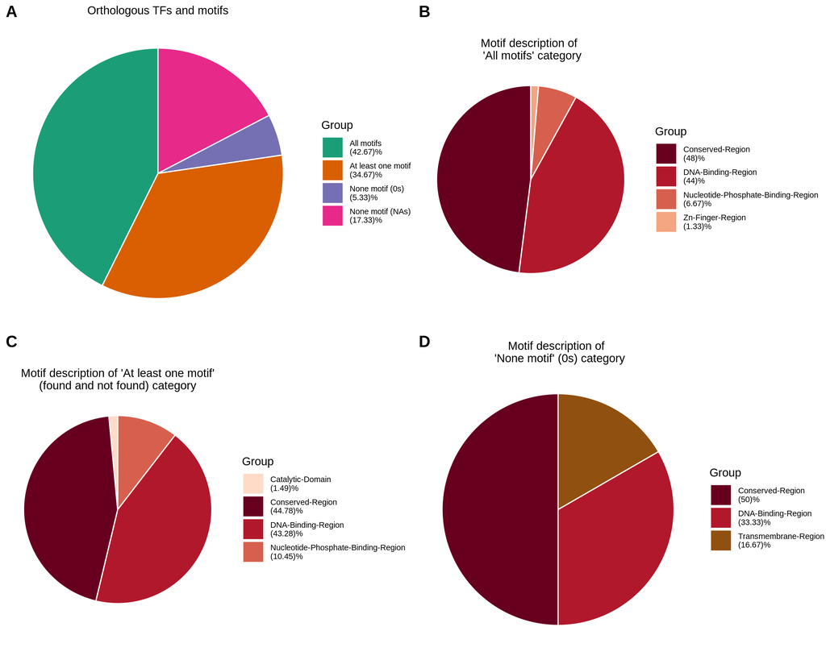

## Requirements in terms of the OS and R libraries

The workflow is implemented in R (**R $\ge$ 4.2.2**) and have dependencies of R packages, Bioconductor packages (**Table 1**).

| OS | R packages | Bioconductor packages |
| --- | --- | --- |
| Windows/linux | dplyr, ggplot2,ggpubr, RColorBrewer, stringr, tidyr | Biostrings |

**Table 1.** Dependencies of the workflow.

## References

Altschul, S F, W Gish, W Miller, E W Myers, and D J Lipman. 1990. “Basic Local Alignment Search Tool.” *Journal of Molecular Biology* 215 (3): 403–10. https://doi.org/10.1016/S0022-2836(05)80360-2.

Dalquen, Daniel A, and Christophe Dessimoz. 2013. “Bidirectional Best Hits Miss Many Orthologs in Duplication-Rich Clades Such as Plants and Animals.” *Genome Biology and Evolution* 5 (10): 1800–1806. https://doi.org/10.1093/gbe/evt132.

Escorcia-Rodríguez, Juan M, Andreas Tauch, and Julio A Freyre-González. 2020. “Abasy Atlas V2.2: The Most Comprehensive and up-to-Date Inventory of Meta-Curated, Historical, Bacterial Regulatory Networks, Their Completeness and System-Level Characterization.” *Computational and Structural Biotechnology Journal* 18 (May): 1228–37. https://doi.org/10.1016/j.csbj.2020.05.015.

Karp, Peter D, Wai Kit Ong, Suzanne Paley, Richard Billington, Ron Caspi, Carol Fulcher, Anamika Kothari, et al. 2018. “The EcoCyc Database.” *EcoSal Plus* 8 (1). https://doi.org/10.1128/ecosalplus.{ESP}-0006-2018.

Koonin, Eugene V. 2005. “Orthologs, Paralogs, and Evolutionary Genomics.” *Annual Review of Genetics* 39: 309–38. https://doi.org/10.1146/annurev.genet.39.073003.114725.

Kuznetsov, Anatoliy, and Colleen J Bollin. 2021. “NCBI Genome Workbench: Desktop Software for Comparative Genomics, Visualization, and Genbank Data Submission.” *Methods in Molecular Biology* 2231: 261–95. https://doi.org/10.1007/978-1-0716-1036-7\_16.

Lin, Jimmy, Donald J Zack, and Jiang Qian. 2006. “Transcriptional Regulatory Network Prediction.” *Biotechnology & Genetic Engineering Reviews* 22: 45–62. https://doi.org/10.1080/02648725.2006.10648064.

Mercatelli, Daniele, Laura Scalambra, Luca Triboli, Forest Ray, and Federico M Giorgi. 2020. “Gene Regulatory Network Inference Resources: A Practical Overview.” *Biochimica Et Biophysica Acta. Gene Regulatory Mechanisms* 1863 (6): 194430. https://doi.org/10.1016/j.bbagrm.2019.194430.

Santos-Zavaleta, Alberto, Heladia Salgado, Socorro Gama-Castro, Mishael Sánchez-Pérez, Laura Gómez-Romero, Daniela Ledezma-Tejeida, Jair Santiago García-Sotelo, et al. 2019. “RegulonDB v 10.5: Tackling Challenges to Unify Classic and High Throughput Knowledge of Gene Regulation in e. Coli k-12.” *Nucleic Acids Research* 47 (D1): D212–20. https://doi.org/10.1093/nar/gky1077.